# Linear modelling of soil temperature effects on root lesion nematode population densities in R

Adam Sparks

7/31/2019

### Adam H Sparks and John P Thompson

University of Southern Queensland, Centre for Crop Health, Toowoomba, Qld, AU

# Introduction

*Pratylenchus thornei*, the root-lesion nematode, is widely distributed in wheat (*Triticum aestivum*) growing areas of many countries and is of particular concern in sub-tropical environments (Thompson 2015). These nematodes penetrate roots to feed and reproduce in the root cortex leading to loss of root function, which affects nutrient and water uptake of nutrients and water causing nutrient deficiency and water stress (Thompson 2015).

In the original paper the population response of *P. thornei* in Queensland, Australia wheat to temperature is modelled using a linear and quadratic equations. The study aimed to investigate the effects of soil profile temperatures after different sowing dates on reproduction of the nematodes in susceptible and moderately resistant wheat cultivars in the subtropical grain region of eastern Australia. This document recreates the models for population densities of *P. thornei* as described in the original paper.

## Objectives

There are two types of models described in the paper, the first model is a linear model used to describe the unplanted control and two quadratic models fit Gatcher (Susceptible) and GS50a (Moderately Resistant) wheat cultivars. For a more detailed discussion on fitting plant disease models in R, please see the “[Linear Regression](http://www.apsnet.org/edcenter/advanced/topics/EcologyAndEpidemiologyInR/DiseaseProgress/Pages/LinearRegression.aspx)” module in the “Ecology and Epidemiology in R” documents available in the American Phytopathological Society’s (APS) Education Center. For an even more in-depth discussion on linear models in R, how to fit and how to interpret the diagnostics that R provides the reader should refer to Faraway (2002).

This post will illustrate how to fit the original linear and quadratic models using the original data in R (R Core Team 2017).

# Packages

Using the **`tidyverse`**, (2017) package simplifies the libraries used in this work. It is a collection of packages designed to work together for data science, https://www.tidyverse.org/. The **`tidyverse`** includes, **`readr`** (2017), used to import the data; **`tidyr`** (2018), used to format the data; **`dplyr`** (2017), used to subset the data; and **`ggplot2`** (2016), used for visualising the data and model fits. **`viridis`** (2018) is a selection of colour pallets that are widely accessible for people with colour-blindness and printing in black and white.

The following code chunk checks first to see if you have **`tidyverse`**, **`viridis`** and **`hrbrthemes`** installed, if not, it will automatically install them and then load them. Then set the default theme for all graphs to `theme_ipsum_rc`.

```r
if (!require(tidyverse)) {
  install.packages(
    "tidyverse",
    repos = c(CRAN = "https://cloud.r-project.org/")
  )
  library(tidyverse)
}

if (!require(viridis)) {
  install.packages(
    "viridis",
    repos = c(CRAN = "https://cloud.r-project.org/")
  )
  library(viridis)
}

if (!require(hrbrthemes)) {
  install.packages(
    "hrbrthemes",
    repos = c(CRAN = "https://cloud.r-project.org/")
  )
  library(hrbrthemes)
}

ggplot2::theme_set(hrbrthemes::theme_ipsum_rc())
```

# Data Wrangling

## Import from csv

The data are located in the `data` sub-folder. Import the data using `read_csv()` function from **`readr`** and view them.

```r
nema <- read_csv("data/Nematode_Data.csv")
nema
```

```
## # A tibble: 24 x 9
##    Weeks  Days Temperature Degree_days Unplanted Gatcher GS50a Potam Suneca
##    <dbl> <dbl>       <dbl>       <dbl>     <dbl>   <dbl> <dbl> <dbl>  <dbl>
##  1     8    56        15           280      5.75    6.77  6.69  7.61   6.70
##  2     8    56        20           560      5.92    9.51  7.42  9.28   9.12
##  3     8    56        22.5         700      6.38    9.96  8.21  9.02  10.0
##  4     8    56        25           840      6.51    9.35  8.25  9.73   9.20
##  5    10    70        15           350      5.85    7.44  6.04  5.97   6.85
##  6    10    70        20           700      6.16   10.3   8.91 10.3   10.2
##  7    10    70        22.5         875      6.19   10.4   9.18 10.7   10.1
##  8    10    70        25          1050      6.36   10.6   9.04 10.5   10.3
##  9    12    84        15           420      5.76    9.93  8.19  8.74   9.57
## 10    12    84        20           840      6.98   11.7   9.85 11.3   11.7
## # ... with 14 more rows
```

```r
nrow(nema)
```

```
## [1] 24
```

```r
summary(nema)
```

```
##      Weeks         Days      Temperature     Degree_days
##  Min.   : 8   Min.   : 56   Min.   :15.00   Min.   : 280.0
##  1st Qu.:10   1st Qu.: 70   1st Qu.:18.75   1st Qu.: 612.5
##  Median :13   Median : 91   Median :21.25   Median : 927.5
##  Mean   :13   Mean   : 91   Mean   :20.62   Mean   : 966.9
##  3rd Qu.:16   3rd Qu.:112   3rd Qu.:23.12   3rd Qu.:1260.0
##  Max.   :18   Max.   :126   Max.   :25.00   Max.   :1890.0
##    Unplanted        Gatcher           GS50a            Potam
##  Min.   :5.748   Min.   : 6.773   Min.   : 6.043   Min.   : 5.972
##  1st Qu.:6.096   1st Qu.:10.191   1st Qu.: 8.248   1st Qu.: 9.944
##  Median :6.635   Median :11.445   Median : 9.604   Median :11.113
##  Mean   :6.667   Mean   :11.214   Mean   : 9.421   Mean   :10.887
##  3rd Qu.:7.205   3rd Qu.:12.943   3rd Qu.:10.395   3rd Qu.:12.443
##  Max.   :8.084   Max.   :13.532   Max.   :11.598   Max.   :13.009
##      Suneca
##  Min.   : 6.703
##  1st Qu.: 9.953
##  Median :10.947
##  Mean   :10.979
##  3rd Qu.:12.797
##  Max.   :13.610
```

## Import from xlxs

```r
library(readxl)
nema2 <- read_excel("data/Nematode_Data.xlsx")
head(nema2)
```

```
## # A tibble: 6 x 9
##   Weeks  Days Temperature Degree_days Unplanted Gatcher GS50a Potam Suneca
##   <dbl> <dbl>       <dbl>       <dbl>     <dbl>   <dbl> <dbl> <dbl>  <dbl>
## 1     8    56        15           280      5.75    6.77  6.69  7.61   6.70
## 2     8    56        20           560      5.92    9.51  7.42  9.28   9.12
## 3     8    56        22.5         700      6.38    9.96  8.21  9.02  10.0
## 4     8    56        25           840      6.51    9.35  8.25  9.73   9.20
## 5    10    70        15           350      5.85    7.44  6.04  5.97   6.85
## 6    10    70        20           700      6.16   10.3   8.91 10.3   10.2
```

## Import from gsheet

```r
library(gsheet)
nema3 <- gsheet2tbl('https://docs.google.com/spreadsheets/d/1ElWVdgeAQb-uLDQUna3IBVWbnhWkgfL26J7-I8oh9oQ/edit?usp=sharing')
```

## Description of Fields in the Data

There are nine columns in the `nema` data described here in the following table.

| Field | Data Description |
| --- | --- |
| Weeks | Number of weeks after wheat sowing |
| Days | Number of days after wheat sowing |
| Temperature | Temperature(°C) treatment |
| Degree_Days | Average thermal time degree days above 10 °C for four soil depths (8, 15, 30 and 60 cm) |
| Unplanted | Log*, `log()`, nematode population in the control treatment with no wheat planted |
| Gatcher | Log*, `log()`, nematode population in a susceptible wheat cultivar |
| GS50a | Log*, `log()`, nematode population in a moderately resistant wheat cultivar |
| Potam | Log*, `log()`, nematode population in a susceptible wheat cultivar |
| Suneca | Log*, `log()`, nematode population in a susceptible wheat cultivar |

## Wide to Long Data

You can see that each of the varieties have their own column in the original data format, this is commonly called wide data. Wide data are commonly found in spreadsheets but do not lend themselves easily to data analysis, modelling and visualisation. To make it easier to do these things it is common to convert the data from wide to long format, commonly referred to as tidying, when using R. The advantage of a tidy dataset is that it is easy to manipulate, model and visualize, and always has a specific structure where each variable is a column, each observation is a row, and each type of observational unit is a table (Wickham 2014).

In order to use **`ggplot2`** for visualising the data, they need to be converted from wide to long. Using `gather()` from the **`tidyr`** package to convert from wide to long format where the varieties are all listed in a single column, `Variety`.

```r
nema_long <- nema %>% gather(Variety, Log_pop, Unplanted:Suneca)

nema_long
```

```
## # A tibble: 120 x 6
##    Weeks  Days Temperature Degree_days Variety   Log_pop
##    <dbl> <dbl>       <dbl>       <dbl> <chr>       <dbl>
##  1     8    56        15           280 Unplanted    5.75
##  2     8    56        20           560 Unplanted    5.92
##  3     8    56        22.5         700 Unplanted    6.38
##  4     8    56        25           840 Unplanted    6.51
##  5    10    70        15           350 Unplanted    5.85
##  6    10    70        20           700 Unplanted    6.16
##  7    10    70        22.5         875 Unplanted    6.19
##  8    10    70        25          1050 Unplanted    6.36
##  9    12    84        15           420 Unplanted    5.76
## 10    12    84        20           840 Unplanted    6.98
## # ... with 110 more rows
```

```r
nrow(nema_long)
```

```
## [1] 120
```

As we see, the original `nema` data had only 24 rows and the long format of the data have 120 rows now.

# Data Visualisation

[output not shown]

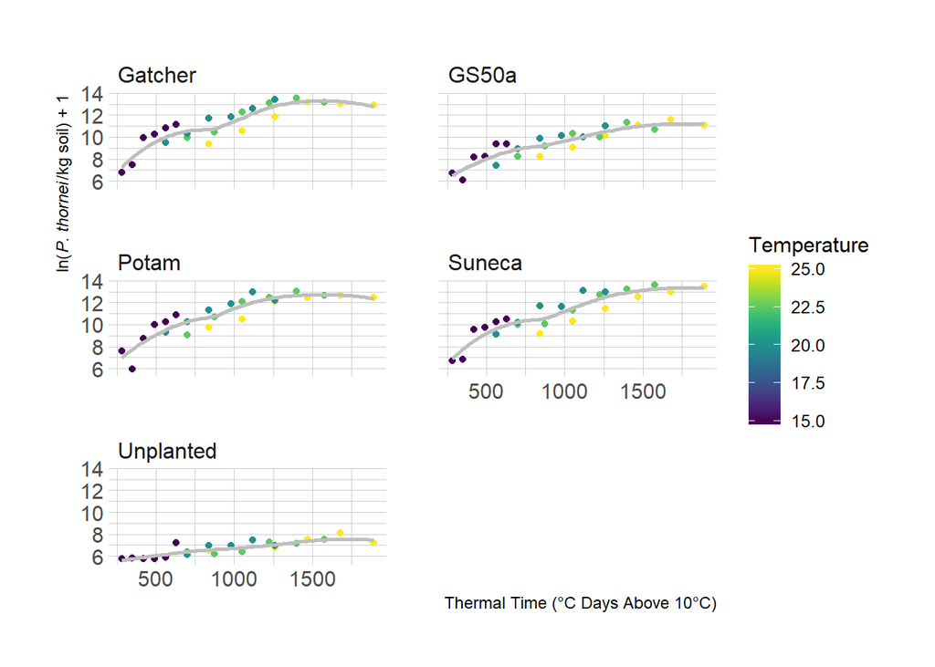

```r
ggplot(
  nema_long,
  aes(
    x = Degree_days,
    y = Log_pop,
    colour = Temperature,
    group = Variety
  )
) +
  geom_point() +
  geom_smooth(
    colour = "grey",
    se = FALSE,
    alpha = 0.5
  ) +
  ylab(expression(
    paste(
      "ln(",
      italic("P. thornei"),
      "/kg soil) + 1"
    ),
    sep = ""
  )) +
  xlab("Thermal Time (˚C Days Above 10˚C)") +
  scale_colour_viridis("Temperature") +
  facet_wrap(~ Variety, ncol = 2)
```

# Modelling

## Unplanted Model

The paper uses a linear model for the unplanted control. Here we will write a function to use in modelling the unplanted population data. I have wrapped the model in a function which makes it pipe-able, `%>%` and has other advantages when it comes to fitting the same model to several sets of data.

In the linear equation for the Unplanted control treatment, the rate of population increase can be expressed as:

$$y = y_0 + rt$$

Where $y_0$ is the initial population, $r$ is the rate of change and $t$ equal time.

### Fitting a Linear Model

```r
linear_model <- function(df) {
  lm(
    Log_pop ~ Degree_days,
    data = df
  )
}
```

Now check the model fit, using `filter()` from **`dplyr`** to select only Unplanted data from the data set for the model and fit the linear model to the data.

```r
unplanted_model <- nema_long %>%
  filter(Variety == "Unplanted") %>%
  linear_model()
```

Using `par(mfrow = c(2, 2))` creates a four-panel graph rather than four individual graphs, which the next function will create by default.

Using the `plot()` function with any `lm()` object will create four diagnostic plots for your inspection.

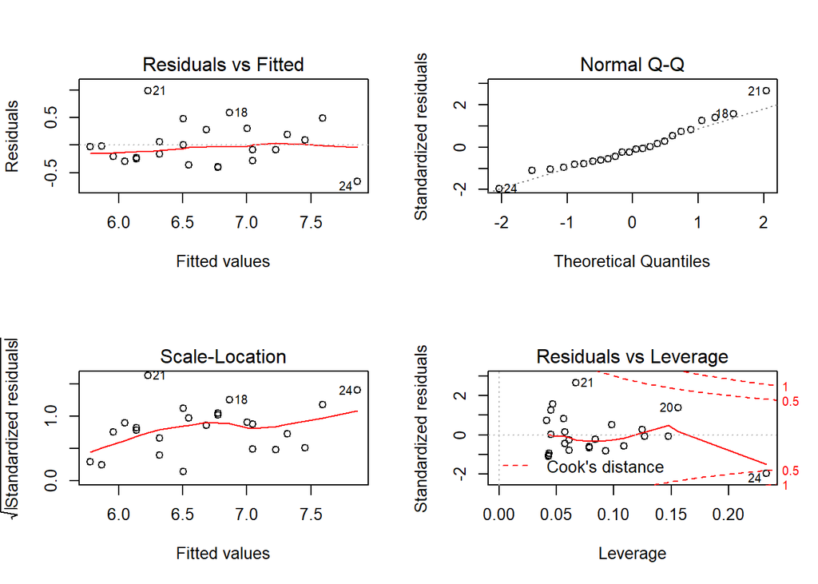

```r
par(mfrow = c(2, 2))
plot(unplanted_model)
```

```r
summary(unplanted_model)
```

```
##
## Call:
## lm(formula = Log_pop ~ Degree_days, data = df)
##
## Residuals:
##      Min       1Q   Median       3Q      Max
## -0.66053 -0.25811 -0.05683  0.21123  0.98511
##
## Coefficients:
##              Estimate Std. Error t value Pr(>|t|)
## (Intercept) 5.4150643  0.1929731  28.061  < 2e-16 ***
## Degree_days 0.0012950  0.0001823   7.103 4.01e-07 ***
## ---
## Signif. codes:  0 '***' 0.001 '**' 0.01 '*' 0.05 '.' 0.1 ' ' 1
##
## Residual standard error: 0.3847 on 22 degrees of freedom
## Multiple R-squared:  0.6964, Adjusted R-squared:  0.6826
## F-statistic: 50.45 on 1 and 22 DF,  p-value: 4.006e-07
```

From the original paper, the $R^2$ value of the unplanted linear model was 0.7, we can see here that agrees: 0.7. In the original paper, $P$ < 0.001, R reports $p-value:$ 4.006382710^{-7}, which also agrees.

#### Visualising the Model Fit to the Data

Using **`ggplot2`**’s `geom_smooth()` we can fit the same model above and graph the resulting line.

[output not shown]

[output cut: 58 more lines]

[output not shown]

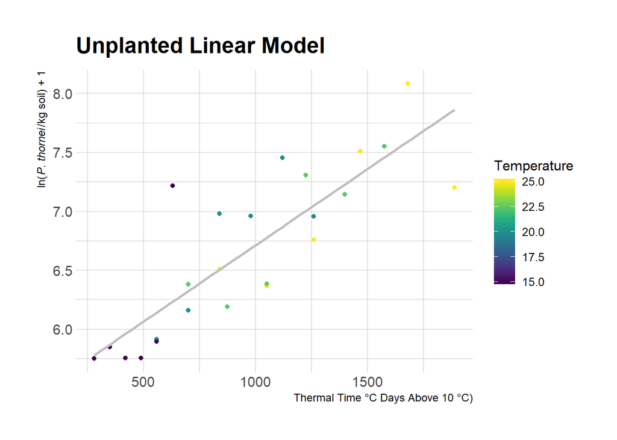

```r
nema_long %>%
  group_by(Variety) %>%
  filter(Variety == "Unplanted") %>%
  ggplot(aes(
    x = Degree_days,
    y = Log_pop,
    colour = Temperature
  )) +
  geom_point() +
  geom_smooth(
    method = "lm",
    formula = y ~ x,
    size = 1,
    se = FALSE,
    colour = "grey",
    alpha = 0.5
  ) +
  ylab(expression(
    paste(
      "ln(",
      italic("P. thornei"),
      "/kg soil) + 1"
    ),
    sep = ""
  )) +
  xlab("Thermal Time ˚C Days Above 10 ˚C)") +
  scale_colour_viridis("Temperature") +
  ggtitle("Unplanted Linear Model")
```

```r
ggsave("figs/fig1-linear-fit.png", dpi = 300)
```

[output not shown]

[output cut: 61 more lines]

[output not shown]

## Quadratic Models

In the original paper, the quadratic model best described Gatcher and GS50a data, which are fit here.

```r
quadratic_model <- function(df) {
  lm(
    Log_pop ~ Degree_days + I(Degree_days ^ 2),
    data = df
  )
}
```

### Susceptible Varieties

Gatcher, Potam and Suneca all have very similar curves, here Gatcher is used to fit a quadratic model as in the original paper following the same methods as above for the linear model.

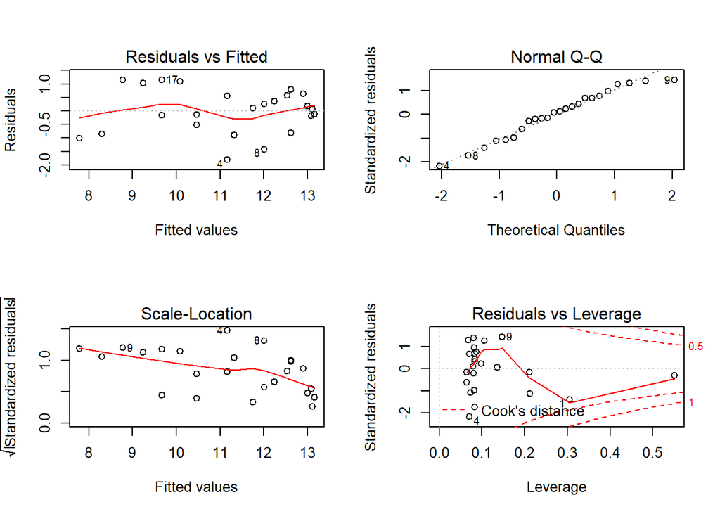

```r
s_model <- nema_long %>%
  filter(Variety == "Gatcher") %>%
  quadratic_model()

par(mfrow = c(2, 2))
plot(s_model)
```

```r
summary(s_model)
```

```
##
## Call:
## lm(formula = Log_pop ~ Degree_days + I(Degree_days^2), data = df)
##
## Residuals:
##      Min       1Q   Median       3Q      Max
## -1.80668 -0.58936  0.07297  0.58228  1.14866
##
## Coefficients:
##                    Estimate Std. Error t value Pr(>|t|)
## (Intercept)       5.476e+00  9.043e-01   6.055 5.21e-06 ***
## Degree_days       8.961e-03  1.909e-03   4.693 0.000124 ***
## I(Degree_days^2) -2.612e-06  9.008e-07  -2.899 0.008579 **
## ---
## Signif. codes:  0 '***' 0.001 '**' 0.01 '*' 0.05 '.' 0.1 ' ' 1
##
## Residual standard error: 0.8631 on 21 degrees of freedom
## Multiple R-squared:  0.7998, Adjusted R-squared:  0.7808
## F-statistic: 41.96 on 2 and 21 DF,  p-value: 4.621e-08
```

From the original paper, the $R^2$ value of Gatcher’s quadratic model was 0.80, we can see here that agrees: 0.8. In the original paper, $P$ < 0.001, R reports $p-value:$ 1.240363510^{-4}, which also agrees.

#### Visualise Susceptible Variety Model

The model visualisation is the same for the quadratic models as the linear model, however you will note that the line has a downward curve at higher temperatures.

[output not shown]

[output cut: 64 more lines]

[output not shown]

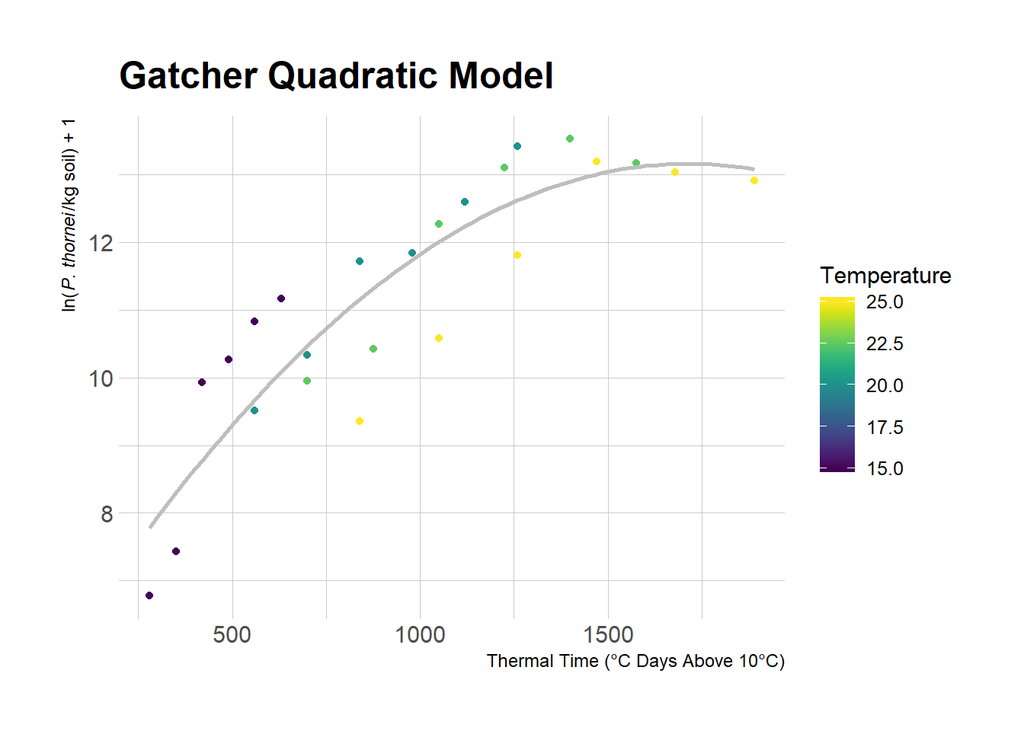

```r
nema_long %>%
  group_by(Variety) %>%
  filter(Variety == "Gatcher") %>%
  ggplot(aes(
    x = Degree_days,
    y = Log_pop,
    colour = Temperature,
  )) +
  geom_point() +
  geom_smooth(
    method = "lm",
    formula = y ~ x + I(x ^ 2),
    size = 1,
    se = FALSE,
    colour = "grey",
    alpha = 0.5
  ) +
  ylab(expression(
    paste(
      "ln(",
      italic("P. thornei"),
      "/kg soil) + 1"
    ),
    sep = ""
  )) +
  xlab("Thermal Time (˚C Days Above 10˚C)") +
  scale_colour_viridis("Temperature") +
  ggtitle("Gatcher Quadratic Model")
```

### Moderately Resistant Cultivar

GS50a, moderately resistant to *P. thornei*, also fits a quadratic model but the coefficients are slightly different due to different responses to the variety and temperature.

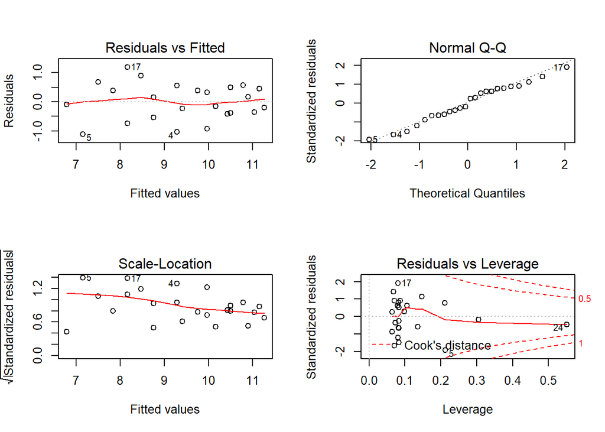

```r
mr_model <- nema_long %>%
  filter(Variety == "GS50a") %>%
  quadratic_model()

par(mfrow = c(2, 2))
plot(mr_model)
```

```r
summary(mr_model)
```

```
##
## Call:
## lm(formula = Log_pop ~ Degree_days + I(Degree_days^2), data = df)
##
## Residuals:
##      Min       1Q   Median       3Q      Max
## -1.11285 -0.39845  0.02889  0.45494  1.18598
##
## Coefficients:
##                    Estimate Std. Error t value Pr(>|t|)
## (Intercept)       5.157e+00  6.779e-01   7.607 1.83e-07 ***
## Degree_days       6.274e-03  1.431e-03   4.384  0.00026 ***
## I(Degree_days^2) -1.609e-06  6.753e-07  -2.383  0.02672 *
## ---
## Signif. codes:  0 '***' 0.001 '**' 0.01 '*' 0.05 '.' 0.1 ' ' 1
##
## Residual standard error: 0.647 on 21 degrees of freedom
## Multiple R-squared:  0.8233, Adjusted R-squared:  0.8065
## F-statistic: 48.92 on 2 and 21 DF,  p-value: 1.248e-08
```

From the original paper, the $R^2$ value of GS50a’s quadratic model was 0.82, we can see here that agrees: 0.82. In the original paper, $P$ < 0.001, R reports $p-value:$ 2.596147310^{-4}, which also agrees.

#### Visualising the Model Fit to the Data

[output not shown]

[output cut: 64 more lines]

[output not shown]

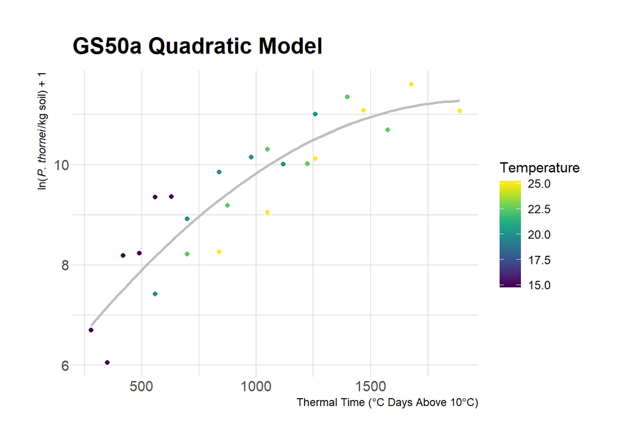

```r
nema_long %>%
  group_by(Variety) %>%
  filter(Variety == "GS50a") %>%
  ggplot(aes(
    x = Degree_days,
    y = Log_pop,
    colour = Temperature,
  )) +
  geom_point() +
  geom_smooth(
    method = "lm",
    formula = y ~ x + I(x ^ 2),
    size = 1,
    se = FALSE,
    colour = "grey",
    alpha = 0.5
  ) +
  ylab(expression(
    paste(
      "ln(",
      italic("P. thornei"),
      "/kg soil) + 1"
    ),
    sep = ""
  )) +
  xlab("Thermal Time (˚C Days Above 10˚C)") +
  scale_colour_viridis("Temperature") +
  ggtitle("GS50a Quadratic Model")
```

# Discussion and Conclusions

As in the original paper, the model equations can be derived from these models as well. The derived regression equations are:

GS50a (Moderately Resistant):
$$ln(P. thornei + 1) = -0.000002(0.0000007)T^2 + 0.0063(0.0014)T + 5.1559(0.678)$$

Unplanted Control:
$$ln(P. thornei + 1) = 0.0013(0.00018)T + 5.4151(0.193)$$

Refer back to the `summary()` outputs for each of the models for the coefficient values and $R^2$ values, which match those reported in the original paper where the models were fit with Genstat.

Gatcher and GS50a have similar phenologies, but differ in resistance to root lesion nematodes, making the model comparisons a reasonable objective. The original paper goes on to test the effect of sowing date based on degree days. (Thompson 2015) reported a 61% increase in yield on average from sowing the susceptible, intolerant cultivar Gatcher at the end of May than sowing it in the third week of June. By June the soil temperatures and nematode populations were both greater, leading to lower wheat yield. The effects were less pronounced in the moderately resistant cultivar, GS50a, but were similar with a reduction in nematode population densities occurring due to earlier planting.

The models illustrated here for Gatcher and GS50a were able to accurately reflect the changes in nematode population as a result of degree days, which affected the nematodes’ ability to damage the crop and reduce yield (Thompson 2015).

# References

Faraway, J. J. 2002. *Practical Regression and Anova using R*. [University of Bath]. Available at: https://cran.r-project.org/doc/contrib/Faraway-PRA.pdf.

Garnier, S. 2018. *Viridis: Default color maps from ’matplotlib’*. Available at: https://CRAN.R-project.org/package=viridis.

R Core Team. 2017. *R: A Language and Environment for Statistical Computing*. Vienna, Austria: R Foundation for Statistical Computing. Available at: https://www.R-project.org/.

Thompson, J. 2015. Modelling population densities of root-lesion nematode (*Pratylenchus thornei*) from soil profile temperatures to choose an optimum sowing date for wheat in a subtropical region. Field Crops Research. 183:50–55 Available at: http://www.sciencedirect.com/science/article/pii/S0378429015300083.

Wickham, H. 2016. *ggplot2: Elegant Graphics for Data Analysis*. Springer-Verlag New York. Available at: http://ggplot2.org.

Wickham, H. 2014. Tidy data. The Journal of Statistical Software. 59 Available at: http://www.jstatsoft.org/v59/i10/.

Wickham, H. 2017. *tidyverse: Easily Install and Load the ’Tidyverse’*. Available at: https://CRAN.R-project.org/package=tidyverse.

Wickham, H., Francois, R., Henry, L., and Müller, K. 2017. *dplyr: A Grammar of Data Manipulation*. Available at: https://CRAN.R-project.org/package=dplyr.

Wickham, H., and Henry, L. 2018. *tidyr: Easily Tidy Data with ’spread()’ and ’gather()’ Functions*. Available at: https://CRAN.R-project.org/package=tidyr.

Wickham, H., Hester, J., and Francois, R. 2017. *readr: Read Rectangular Text Data*. Available at: https://CRAN.R-project.org/package=readr.